# Reproducible Research: Peer Assessment 1

roei fredo

March 2, 2019

# Introduction

It is now possible to collect a large amount of data about personal movement using activity monitoring devices such as a Fitbit, Nike Fuelband, or Jawbone Up. These type of devices are part of the “quantified self” movement – a group of enthusiasts who take measurements about themselves regularly to improve their health, to find patterns in their behavior.

This assignment makes use of data from a personal activity monitoring device. This device collects data at 5 minute intervals through out the day. The data consists of two months of data from an anonymous individual collected during the months of October and November, 2012 and include the number of steps taken in 5 minute intervals each day.

# Data

The variables included in this dataset are:

- steps: Number of steps taking in a 5-minute interval (missing values are coded as NA)
- date: The date on which the measurement was taken in YYYY-MM-DD format
- interval: Identifier for the 5-minute interval in which measurement was taken

The dataset is stored in a comma-separated-value (CSV) file and there are a total of 17,568 observations in this dataset.

# Assignment

first we will set some global options

```r
knitr::opts_chunk$set(echo = TRUE)
```

## loading and processing the data

and then, read the data into r:

```r
if(!dir.exists("C:/Users/roeifredo/Documents/reproducible research/Assignment1")) {
    dir.create("C:/Users/roeifredo/Documents/reproducible research/Assignment1")
    file.move("C:/Users/roeifredo/Downloads/repdata_data_activity.zip",
              "C:/Users/roeifredo/Documents/reproducible research")

}
setwd("C:/Users/roeifredo/Documents/reproducible research/Assignment1")

if(!file.exists("C:/Users/roeifredo/Documents/reproducible research/Assignment1/activity.csv")){
    unzip("C:/Users/roeifredo/Documents/reproducible research/Assignment1/repdata_data_activity.zip"
          ,exdir = getwd())

}
activity <- read.csv("./activity.csv")
summary(activity)
```

```
##      steps                date          interval
##  Min.   :  0.00   2012-10-01:  288   Min.   :   0.0
##  1st Qu.:  0.00   2012-10-02:  288   1st Qu.: 588.8
##  Median :  0.00   2012-10-03:  288   Median :1177.5
##  Mean   : 37.38   2012-10-04:  288   Mean   :1177.5
##  3rd Qu.: 12.00   2012-10-05:  288   3rd Qu.:1766.2
##  Max.   :806.00   2012-10-06:  288   Max.   :2355.0
##  NA's   :2304     (Other)   :15840
```

```r
str(activity)
```

```
## 'data.frame':    17568 obs. of  3 variables:
##  $ steps   : int  NA NA NA NA NA NA NA NA NA NA ...
##  $ date    : Factor w/ 61 levels "2012-10-01","2012-10-02",..: 1 1 1 1 1 1 1 1 1 1 ...
##  $ interval: int  0 5 10 15 20 25 30 35 40 45 ...
```

## What is mean total number of steps taken per day?

first we will show a histogram of total number of steps taken each day

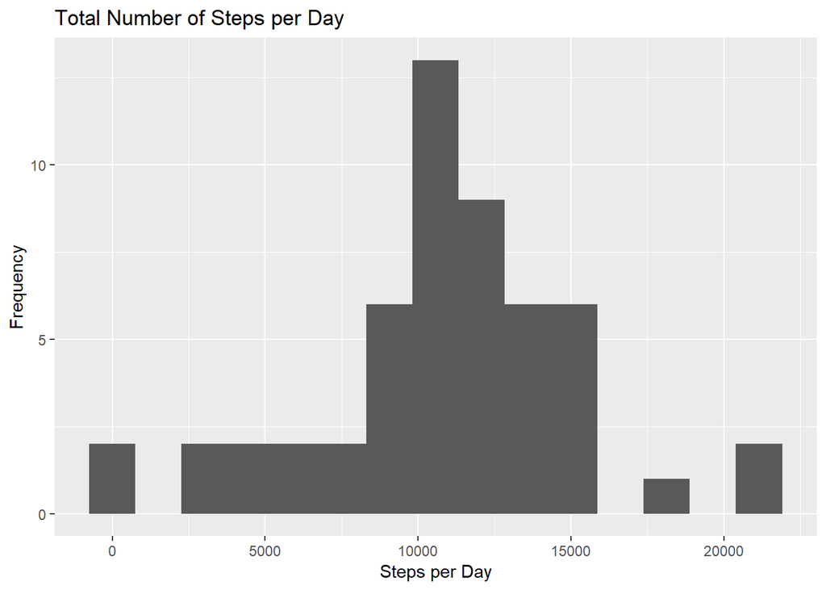

```r
active_by_date <- summarize(group_by(activity, date), total_steps = sum(steps))
g = ggplot(active_by_date, aes(total_steps))
g + geom_histogram(bins = 15) +
    labs(title = "Total Number of Steps per Day", x = "Steps per Day", y = "Frequency")
```

then, we will calculate the mean and median values for total daily steps

```r
mean_steps <- mean(active_by_date$total_steps, na.rm = T)
median_steps <- median(active_by_date$total_steps, na.rm = T)
```

## What is the average daily activity pattern?

first we will plot the mean steps taken by the subject per interval:

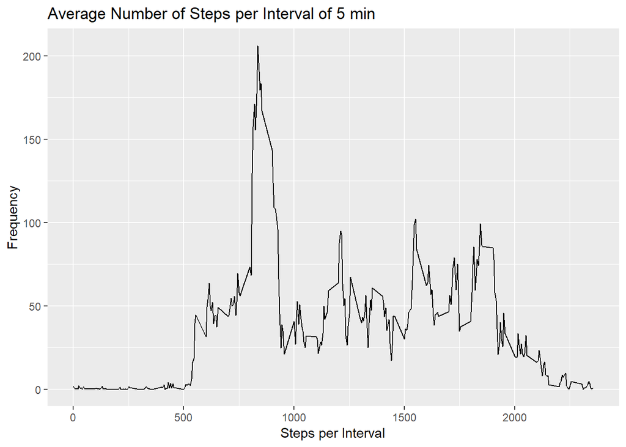

```r
active_by_interval <- summarize(group_by(activity, interval), average_steps = mean(steps, na.rm = T))
g <- ggplot(active_by_interval, aes(interval, average_steps))
g + geom_line()+ labs(title = "Average Number of Steps per Interval of 5 min", x = "Steps per Interval", y = "Frequency")
```

then, we will find the value for the busiest interval:

```r
mean_per_interval <- active_by_interval[which.max(active_by_interval$average_steps), 1]
```

The 835th interval, is, on average the most active interval for the chosen subject

## Imputing missing values

```r
NA_count <- sum(complete.cases(activity))
```

next, we will replace NA values with the mean for 5-minute interval and create a new dataset W/O NA values

```r
activity1 <- merge(activity, active_by_interval, by = "interval", sort = T)
activity1 <- arrange(activity1, date, interval)
activity1_NAs <- which(is.na(activity1$steps))
for(i in activity1_NAs) {
    activity1[i, 2] <- activity1[i, 4]
}
activity1 <- activity1[, c(2,3,1)]

print(head(activity1))
```

```
##       steps       date interval
## 1 1.7169811 2012-10-01        0
## 2 0.3396226 2012-10-01        5
## 3 0.1320755 2012-10-01       10
## 4 0.1509434 2012-10-01       15
## 5 0.0754717 2012-10-01       20
## 6 2.0943396 2012-10-01       25
```

Now, we will analyse the new NA-free dataset and show a histogram of total number of steps taken each day

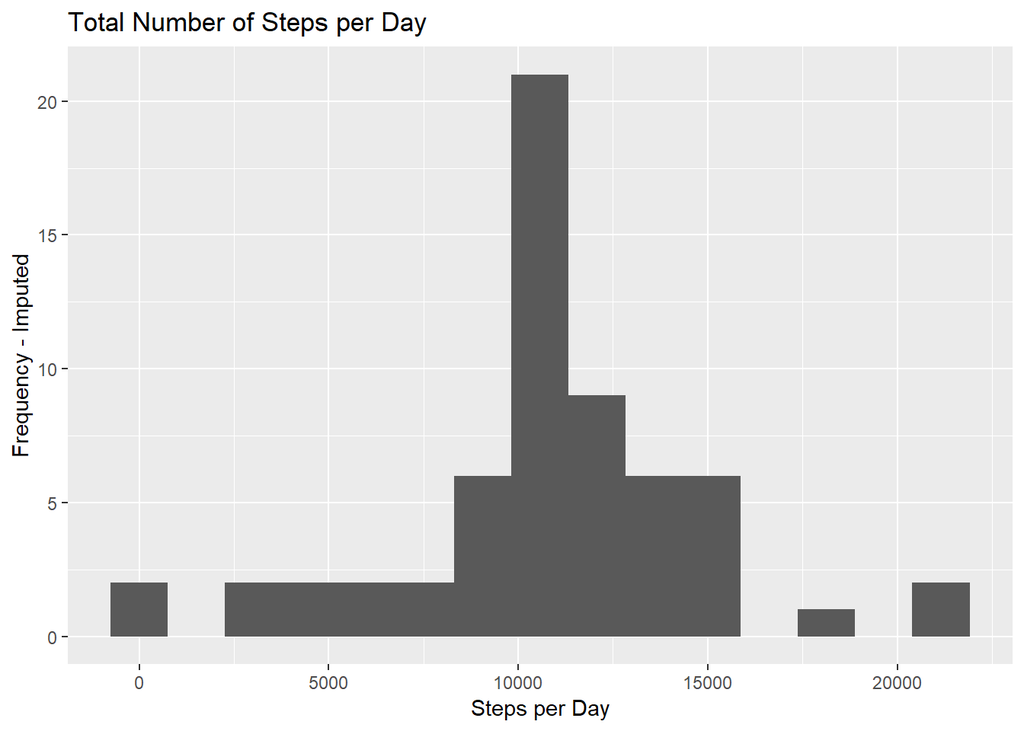

```r
active_by_date_imp <- summarize(group_by(activity1, date), total_steps = sum(steps))
g = ggplot(active_by_date_imp, aes(total_steps))
g + geom_histogram(bins = 15) +
    labs(title = "Total Number of Steps per Day", x = "Steps per Day", y = "Frequency - Imputed")
```

then, we will calculate again the mean and median values for total daily steps

```r
mean_steps1 <- mean(active_by_date_imp$total_steps, na.rm = T)
median_steps1 <- median(active_by_date_imp$total_steps, na.rm = T)
```

```r
mean_median_compare <- data.frame(c(mean_steps, median_steps), c(mean_steps1, median_steps1))
colnames(mean_median_compare) <- c("NA removed", "NA imputed")
rownames(mean_median_compare) <- c("mean", "median")
xt <- xtable(mean_median_compare)
print(xt, "html")
```

|  | NA removed | NA imputed |
| --- | --- | --- |
| mean | 10766.19 | 10766.19 |
| median | 10765.00 | 10766.19 |

As we can see, when comparing between dataset before and after replacing NAs, there is no difference in mean values and a small difference in median values.

## Are there differences in activity patterns between weekdays and weekends?

first we will create a new binary variable indicating a given date as a weekday or a weekend day:

```r
activity1$day_type <- as.factor(ifelse(weekdays(as.Date(activity1$date)) %in%
c("Monday", "Tuesday", "Wednesday", "Thursday","Friday"), yes = "weekday", no = "weekend"))
head(activity1)
```

```
##       steps       date interval day_type
## 1 1.7169811 2012-10-01        0  weekday
## 2 0.3396226 2012-10-01        5  weekday
## 3 0.1320755 2012-10-01       10  weekday
## 4 0.1509434 2012-10-01       15  weekday
## 5 0.0754717 2012-10-01       20  weekday
## 6 2.0943396 2012-10-01       25  weekday
```

next, we will plot the average number of steps taken across weekdays and weekend

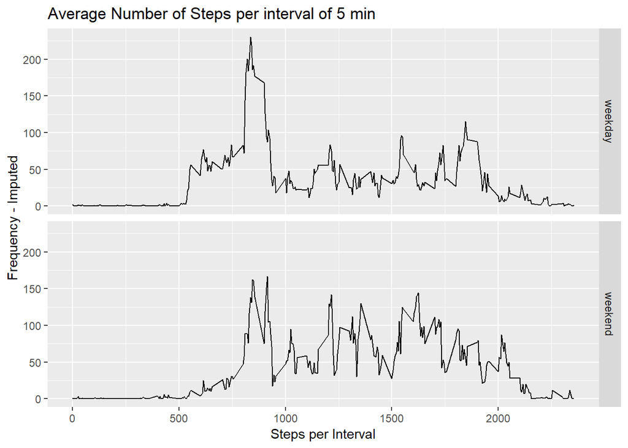

```r
active_by_interval_type <- summarize(group_by(activity1, interval, day_type), average_steps = mean(steps, na.rm = T))
g <- ggplot(active_by_interval_type, aes(interval, average_steps))
g + geom_line() + facet_grid(day_type ~ .) +
    labs(title = "Average Number of Steps per interval of 5 min", x = "Steps per Interval", y = "Frequency - Imputed")
```

As we can see, during weekdays the subject has an early start, that peaks between 8am-9am. during the weekend, there more activity in later hours- activity is more spread along the day